# Risk Factor Analysis

## Outcome Variable

**Outcome Variable:** whz

## Predictor Variables

**Intervention Variable:** hdlvry

**Adjustment Set:**

- arm
- sex
- W_mage
- meducyrs
- feducyrs
- hhwealth_quart
- single
- W_nrooms
- brthmon
- W_parity
- impsan
- delta_W_mage
- delta_meducyrs
- delta_feducyrs
- delta_hhwealth_quart
- delta_single
- delta_W_nrooms
- delta_brthmon
- delta_W_parity
- delta_impsan

## Stratifying Variables

The analysis was stratified on these variable(s):

- agecat
- studyid
- country

## Data Summary

| agecat | studyid | country | hdlvry | n_cell | n | outcome_variable |
| --- | --- | --- | --- | --- | --- | --- |
| Birth | ki1000108-CMC-V-BCS-2002 | INDIA | 0 | 86 | 86 | whz |
| Birth | ki1000108-CMC-V-BCS-2002 | INDIA | 1 | 0 | 86 | whz |
| Birth | ki1000108-IRC | INDIA | 0 | 337 | 343 | whz |
| Birth | ki1000108-IRC | INDIA | 1 | 6 | 343 | whz |
| Birth | ki1000109-EE | PAKISTAN | 0 | 120 | 175 | whz |
| Birth | ki1000109-EE | PAKISTAN | 1 | 55 | 175 | whz |
| Birth | ki1000304b-SAS-CompFeed | INDIA | 0 | 108 | 957 | whz |
| Birth | ki1000304b-SAS-CompFeed | INDIA | 1 | 849 | 957 | whz |
| Birth | ki1017093b-PROVIDE | BANGLADESH | 0 | 387 | 532 | whz |
| Birth | ki1017093b-PROVIDE | BANGLADESH | 1 | 145 | 532 | whz |
| Birth | ki1017093c-NIH-Crypto | BANGLADESH | 0 | 548 | 707 | whz |
| Birth | ki1017093c-NIH-Crypto | BANGLADESH | 1 | 159 | 707 | whz |
| Birth | ki1113344-GMS-Nepal | NEPAL | 0 | 143 | 596 | whz |
| Birth | ki1113344-GMS-Nepal | NEPAL | 1 | 453 | 596 | whz |
| Birth | ki1135781-COHORTS | INDIA | 0 | 2763 | 4389 | whz |
| Birth | ki1135781-COHORTS | INDIA | 1 | 1626 | 4389 | whz |
| Birth | kiGH5241-JiVitA-3 | BANGLADESH | 0 | 27 | 292 | whz |
| Birth | kiGH5241-JiVitA-3 | BANGLADESH | 1 | 265 | 292 | whz |
| Birth | kiGH5241-JiVitA-4 | BANGLADESH | 0 | 500 | 2384 | whz |
| Birth | kiGH5241-JiVitA-4 | BANGLADESH | 1 | 1884 | 2384 | whz |
| 6 months | ki1000108-CMC-V-BCS-2002 | INDIA | 0 | 357 | 365 | whz |
| 6 months | ki1000108-CMC-V-BCS-2002 | INDIA | 1 | 8 | 365 | whz |
| 6 months | ki1000108-IRC | INDIA | 0 | 400 | 408 | whz |
| 6 months | ki1000108-IRC | INDIA | 1 | 8 | 408 | whz |
| 6 months | ki1000109-EE | PAKISTAN | 0 | 252 | 373 | whz |
| 6 months | ki1000109-EE | PAKISTAN | 1 | 121 | 373 | whz |
| 6 months | ki1000304b-SAS-CompFeed | INDIA | 0 | 147 | 1088 | whz |
| 6 months | ki1000304b-SAS-CompFeed | INDIA | 1 | 941 | 1088 | whz |
| 6 months | ki1000304b-SAS-FoodSuppl | INDIA | 0 | 76 | 380 | whz |
| 6 months | ki1000304b-SAS-FoodSuppl | INDIA | 1 | 304 | 380 | whz |
| 6 months | ki1017093b-PROVIDE | BANGLADESH | 0 | 450 | 603 | whz |
| 6 months | ki1017093b-PROVIDE | BANGLADESH | 1 | 153 | 603 | whz |
| 6 months | ki1017093c-NIH-Crypto | BANGLADESH | 0 | 554 | 715 | whz |
| 6 months | ki1017093c-NIH-Crypto | BANGLADESH | 1 | 161 | 715 | whz |
| 6 months | ki1066203-TanzaniaChild2 | TANZANIA, UNITED REPUBLIC OF | 0 | 1888 | 1920 | whz |
| 6 months | ki1066203-TanzaniaChild2 | TANZANIA, UNITED REPUBLIC OF | 1 | 32 | 1920 | whz |
| 6 months | ki1113344-GMS-Nepal | NEPAL | 0 | 129 | 528 | whz |
| 6 months | ki1113344-GMS-Nepal | NEPAL | 1 | 399 | 528 | whz |
| 6 months | ki1135781-COHORTS | INDIA | 0 | 2896 | 4694 | whz |
| 6 months | ki1135781-COHORTS | INDIA | 1 | 1798 | 4694 | whz |
| 6 months | kiGH5241-JiVitA-3 | BANGLADESH | 0 | 39 | 334 | whz |
| 6 months | kiGH5241-JiVitA-3 | BANGLADESH | 1 | 295 | 334 | whz |
| 6 months | kiGH5241-JiVitA-4 | BANGLADESH | 0 | 1082 | 4042 | whz |
| 6 months | kiGH5241-JiVitA-4 | BANGLADESH | 1 | 2960 | 4042 | whz |
| 24 months | ki1000108-CMC-V-BCS-2002 | INDIA | 0 | 361 | 369 | whz |
| 24 months | ki1000108-CMC-V-BCS-2002 | INDIA | 1 | 8 | 369 | whz |
| 24 months | ki1000108-IRC | INDIA | 0 | 401 | 409 | whz |
| 24 months | ki1000108-IRC | INDIA | 1 | 8 | 409 | whz |
| 24 months | ki1000109-EE | PAKISTAN | 0 | 112 | 167 | whz |
| 24 months | ki1000109-EE | PAKISTAN | 1 | 55 | 167 | whz |
| 24 months | ki1017093b-PROVIDE | BANGLADESH | 0 | 433 | 579 | whz |
| 24 months | ki1017093b-PROVIDE | BANGLADESH | 1 | 146 | 579 | whz |
| 24 months | ki1017093c-NIH-Crypto | BANGLADESH | 0 | 391 | 514 | whz |
| 24 months | ki1017093c-NIH-Crypto | BANGLADESH | 1 | 123 | 514 | whz |
| 24 months | ki1066203-TanzaniaChild2 | TANZANIA, UNITED REPUBLIC OF | 0 | 6 | 6 | whz |
| 24 months | ki1066203-TanzaniaChild2 | TANZANIA, UNITED REPUBLIC OF | 1 | 0 | 6 | whz |
| 24 months | ki1113344-GMS-Nepal | NEPAL | 0 | 118 | 455 | whz |
| 24 months | ki1113344-GMS-Nepal | NEPAL | 1 | 337 | 455 | whz |
| 24 months | ki1135781-COHORTS | INDIA | 0 | 2214 | 3533 | whz |
| 24 months | ki1135781-COHORTS | INDIA | 1 | 1319 | 3533 | whz |
| 24 months | kiGH5241-JiVitA-3 | BANGLADESH | 0 | 34 | 289 | whz |
| 24 months | kiGH5241-JiVitA-3 | BANGLADESH | 1 | 255 | 289 | whz |
| 24 months | kiGH5241-JiVitA-4 | BANGLADESH | 0 | 1032 | 3993 | whz |
| 24 months | kiGH5241-JiVitA-4 | BANGLADESH | 1 | 2961 | 3993 | whz |

The following strata were considered:

- agecat: 24 months, studyid: ki1000108-CMC-V-BCS-2002, country: INDIA
- agecat: 24 months, studyid: ki1000108-IRC, country: INDIA
- agecat: 24 months, studyid: ki1000109-EE, country: PAKISTAN
- agecat: 24 months, studyid: ki1017093b-PROVIDE, country: BANGLADESH
- agecat: 24 months, studyid: ki1017093c-NIH-Crypto, country: BANGLADESH
- agecat: 24 months, studyid: ki1066203-TanzaniaChild2, country: TANZANIA, UNITED REPUBLIC OF
- agecat: 24 months, studyid: ki1113344-GMS-Nepal, country: NEPAL
- agecat: 24 months, studyid: ki1135781-COHORTS, country: INDIA
- agecat: 24 months, studyid: kiGH5241-JiVitA-3, country: BANGLADESH
- agecat: 24 months, studyid: kiGH5241-JiVitA-4, country: BANGLADESH
- agecat: 6 months, studyid: ki1000108-CMC-V-BCS-2002, country: INDIA
- agecat: 6 months, studyid: ki1000108-IRC, country: INDIA
- agecat: 6 months, studyid: ki1000109-EE, country: PAKISTAN
- agecat: 6 months, studyid: ki1000304b-SAS-CompFeed, country: INDIA
- agecat: 6 months, studyid: ki1000304b-SAS-FoodSuppl, country: INDIA
- agecat: 6 months, studyid: ki1017093b-PROVIDE, country: BANGLADESH
- agecat: 6 months, studyid: ki1017093c-NIH-Crypto, country: BANGLADESH
- agecat: 6 months, studyid: ki1066203-TanzaniaChild2, country: TANZANIA, UNITED REPUBLIC OF
- agecat: 6 months, studyid: ki1113344-GMS-Nepal, country: NEPAL
- agecat: 6 months, studyid: ki1135781-COHORTS, country: INDIA
- agecat: 6 months, studyid: kiGH5241-JiVitA-3, country: BANGLADESH
- agecat: 6 months, studyid: kiGH5241-JiVitA-4, country: BANGLADESH
- agecat: Birth, studyid: ki1000108-CMC-V-BCS-2002, country: INDIA
- agecat: Birth, studyid: ki1000108-IRC, country: INDIA
- agecat: Birth, studyid: ki1000109-EE, country: PAKISTAN
- agecat: Birth, studyid: ki1000304b-SAS-CompFeed, country: INDIA
- agecat: Birth, studyid: ki1017093b-PROVIDE, country: BANGLADESH
- agecat: Birth, studyid: ki1017093c-NIH-Crypto, country: BANGLADESH
- agecat: Birth, studyid: ki1113344-GMS-Nepal, country: NEPAL
- agecat: Birth, studyid: ki1135781-COHORTS, country: INDIA
- agecat: Birth, studyid: kiGH5241-JiVitA-3, country: BANGLADESH
- agecat: Birth, studyid: kiGH5241-JiVitA-4, country: BANGLADESH

### Dropped Strata

- agecat: Birth, studyid: ki1000108-CMC-V-BCS-2002, country: INDIA
- agecat: 24 months, studyid: ki1066203-TanzaniaChild2, country: TANZANIA, UNITED REPUBLIC OF

## Methods Detail

We’re interested in the causal parameters $E[Y_a]$ for all values of $a \in \mathcal{A}$. These parameters represent the mean outcome if, possibly contrary to fact, we intervened to set all units to have $A=a$. Under the randomization and positivity assumptions, these are identified by the statistical parameters $\psi_a=E_W[E_{Y|A,W}(Y|A=a,W)]$. In addition, we’re interested in the mean of $Y$, $E[Y]$ under no intervention (the observed mean). We will estimate these parameters by using SuperLearner to fit the relevant likelihood factors – $E_{Y|A,W}(Y|A=a,W)$ and $p(A=a|W)$, and then updating our likelihood fit using a joint TMLE.

For unadjusted analyses ($W=\{\}$), initial likelihoods were estimated using Lrnr_glm to estimate the simple $E(Y|A)$ and Lrnr_mean to estimate $p(A)$. For adjusted analyses, a small library containing Lrnr_glmnet, Lrnr_xgboost, and Lrnr_mean was used.

Having estimated these parameters, we will then use the delta method to estimate relative risks and attributable risks relative to a prespecified baseline level of $A$.

# Results Detail

## Results Plots

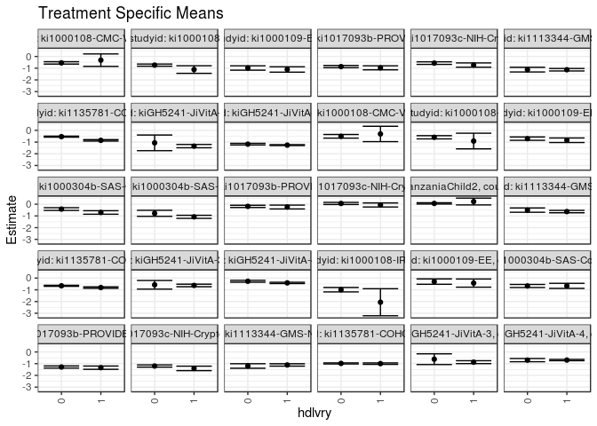

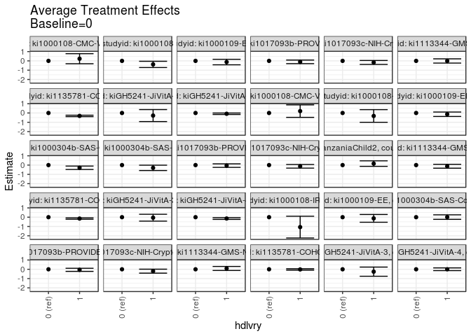

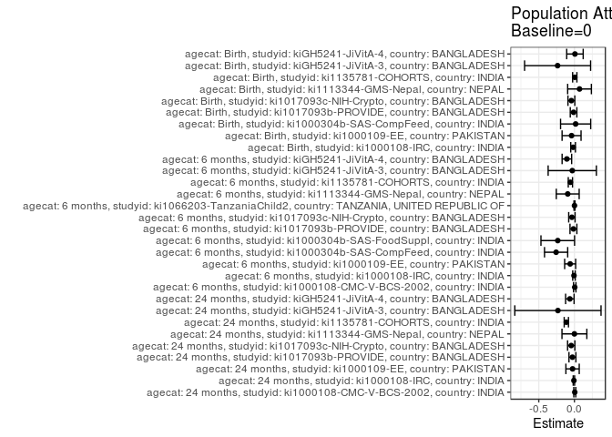

## Results Table

### Parameter: TSM

| agecat | studyid | country | intervention_level | baseline_level | estimate | ci_lower | ci_upper |
| --- | --- | --- | --- | --- | --- | --- | --- |
| Birth | ki1000108-IRC | INDIA | 0 | NA | -0.9918991 | -1.1804921 | -0.8033061 |
| Birth | ki1000108-IRC | INDIA | 1 | NA | -2.0600000 | -3.2141159 | -0.9058841 |
| Birth | ki1000109-EE | PAKISTAN | 0 | NA | -0.3009036 | -0.5296753 | -0.0721318 |
| Birth | ki1000109-EE | PAKISTAN | 1 | NA | -0.4275750 | -0.7750266 | -0.0801234 |
| Birth | ki1000304b-SAS-CompFeed | INDIA | 0 | NA | -0.6740938 | -0.8050105 | -0.5431772 |
| Birth | ki1000304b-SAS-CompFeed | INDIA | 1 | NA | -0.6629343 | -0.8796010 | -0.4462675 |
| Birth | ki1017093b-PROVIDE | BANGLADESH | 0 | NA | -1.2863908 | -1.3775808 | -1.1952007 |
| Birth | ki1017093b-PROVIDE | BANGLADESH | 1 | NA | -1.3424662 | -1.4829709 | -1.2019616 |
| Birth | ki1017093c-NIH-Crypto | BANGLADESH | 0 | NA | -1.2015906 | -1.2956822 | -1.1074990 |
| Birth | ki1017093c-NIH-Crypto | BANGLADESH | 1 | NA | -1.4021358 | -1.5929093 | -1.2113623 |
| Birth | ki1113344-GMS-Nepal | NEPAL | 0 | NA | -1.1992707 | -1.3911940 | -1.0073473 |
| Birth | ki1113344-GMS-Nepal | NEPAL | 1 | NA | -1.1093820 | -1.2109589 | -1.0078051 |
| Birth | ki1135781-COHORTS | INDIA | 0 | NA | -0.9804000 | -1.0268812 | -0.9339187 |
| Birth | ki1135781-COHORTS | INDIA | 1 | NA | -0.9961279 | -1.0585196 | -0.9337362 |
| Birth | kiGH5241-JiVitA-3 | BANGLADESH | 0 | NA | -0.6172019 | -1.0747269 | -0.1596769 |
| Birth | kiGH5241-JiVitA-3 | BANGLADESH | 1 | NA | -0.8722268 | -0.9971024 | -0.7473512 |
| Birth | kiGH5241-JiVitA-4 | BANGLADESH | 0 | NA | -0.6979600 | -0.8338164 | -0.5621036 |
| Birth | kiGH5241-JiVitA-4 | BANGLADESH | 1 | NA | -0.6933576 | -0.7484661 | -0.6382491 |
| 6 months | ki1000108-CMC-V-BCS-2002 | INDIA | 0 | NA | -0.5089262 | -0.6640006 | -0.3538519 |
| 6 months | ki1000108-CMC-V-BCS-2002 | INDIA | 1 | NA | -0.3072917 | -0.9616161 | 0.3470328 |
| 6 months | ki1000108-IRC | INDIA | 0 | NA | -0.5926333 | -0.7305001 | -0.4547666 |
| 6 months | ki1000108-IRC | INDIA | 1 | NA | -0.9137500 | -1.5807163 | -0.2467837 |
| 6 months | ki1000109-EE | PAKISTAN | 0 | NA | -0.7097690 | -0.8524169 | -0.5671212 |
| 6 months | ki1000109-EE | PAKISTAN | 1 | NA | -0.8443223 | -1.0369578 | -0.6516867 |
| 6 months | ki1000304b-SAS-CompFeed | INDIA | 0 | NA | -0.4164458 | -0.5327295 | -0.3001621 |
| 6 months | ki1000304b-SAS-CompFeed | INDIA | 1 | NA | -0.7045253 | -0.8526779 | -0.5563727 |
| 6 months | ki1000304b-SAS-FoodSuppl | INDIA | 0 | NA | -0.7785495 | -1.0346834 | -0.5224157 |
| 6 months | ki1000304b-SAS-FoodSuppl | INDIA | 1 | NA | -1.0766047 | -1.2073573 | -0.9458522 |
| 6 months | ki1017093b-PROVIDE | BANGLADESH | 0 | NA | -0.1853247 | -0.2811718 | -0.0894777 |
| 6 months | ki1017093b-PROVIDE | BANGLADESH | 1 | NA | -0.2413626 | -0.4051903 | -0.0775348 |
| 6 months | ki1017093c-NIH-Crypto | BANGLADESH | 0 | NA | 0.0652385 | -0.0240061 | 0.1544831 |
| 6 months | ki1017093c-NIH-Crypto | BANGLADESH | 1 | NA | -0.0649827 | -0.2380434 | 0.1080780 |
| 6 months | ki1066203-TanzaniaChild2 | TANZANIA, UNITED REPUBLIC OF | 0 | NA | 0.0679948 | 0.0129453 | 0.1230444 |
| 6 months | ki1066203-TanzaniaChild2 | TANZANIA, UNITED REPUBLIC OF | 1 | NA | 0.2279651 | -0.0631089 | 0.5190392 |
| 6 months | ki1113344-GMS-Nepal | NEPAL | 0 | NA | -0.5052692 | -0.6887035 | -0.3218350 |
| 6 months | ki1113344-GMS-Nepal | NEPAL | 1 | NA | -0.6289365 | -0.7304883 | -0.5273847 |
| 6 months | ki1135781-COHORTS | INDIA | 0 | NA | -0.6595297 | -0.7034290 | -0.6156304 |
| 6 months | ki1135781-COHORTS | INDIA | 1 | NA | -0.8074305 | -0.8685434 | -0.7463177 |
| 6 months | kiGH5241-JiVitA-3 | BANGLADESH | 0 | NA | -0.5742260 | -0.9427758 | -0.2056762 |
| 6 months | kiGH5241-JiVitA-3 | BANGLADESH | 1 | NA | -0.6294545 | -0.7379730 | -0.5209360 |
| 6 months | kiGH5241-JiVitA-4 | BANGLADESH | 0 | NA | -0.2702943 | -0.3497458 | -0.1908428 |
| 6 months | kiGH5241-JiVitA-4 | BANGLADESH | 1 | NA | -0.4121896 | -0.4657512 | -0.3586280 |
| 24 months | ki1000108-CMC-V-BCS-2002 | INDIA | 0 | NA | -0.5487673 | -0.6500596 | -0.4474751 |
| 24 months | ki1000108-CMC-V-BCS-2002 | INDIA | 1 | NA | -0.3150000 | -0.8468853 | 0.2168853 |
| 24 months | ki1000108-IRC | INDIA | 0 | NA | -0.7384331 | -0.8312559 | -0.6456103 |
| 24 months | ki1000108-IRC | INDIA | 1 | NA | -1.1158333 | -1.4387631 | -0.7929036 |
| 24 months | ki1000109-EE | PAKISTAN | 0 | NA | -0.9842699 | -1.1695237 | -0.7990162 |
| 24 months | ki1000109-EE | PAKISTAN | 1 | NA | -1.1082105 | -1.3386140 | -0.8778070 |
| 24 months | ki1017093b-PROVIDE | BANGLADESH | 0 | NA | -0.8650653 | -0.9600677 | -0.7700630 |
| 24 months | ki1017093b-PROVIDE | BANGLADESH | 1 | NA | -0.9697040 | -1.1393178 | -0.8000903 |
| 24 months | ki1017093c-NIH-Crypto | BANGLADESH | 0 | NA | -0.5654748 | -0.6761814 | -0.4547682 |
| 24 months | ki1017093c-NIH-Crypto | BANGLADESH | 1 | NA | -0.7323372 | -0.9137644 | -0.5509100 |
| 24 months | ki1113344-GMS-Nepal | NEPAL | 0 | NA | -1.1235825 | -1.3247924 | -0.9223726 |
| 24 months | ki1113344-GMS-Nepal | NEPAL | 1 | NA | -1.1312827 | -1.2367097 | -1.0258556 |
| 24 months | ki1135781-COHORTS | INDIA | 0 | NA | -0.5385266 | -0.5831044 | -0.4939489 |
| 24 months | ki1135781-COHORTS | INDIA | 1 | NA | -0.8530166 | -0.9144716 | -0.7915616 |
| 24 months | kiGH5241-JiVitA-3 | BANGLADESH | 0 | NA | -1.0674498 | -1.7349565 | -0.3999432 |
| 24 months | kiGH5241-JiVitA-3 | BANGLADESH | 1 | NA | -1.3457700 | -1.4864307 | -1.2051093 |
| 24 months | kiGH5241-JiVitA-4 | BANGLADESH | 0 | NA | -1.1779146 | -1.2484207 | -1.1074086 |
| 24 months | kiGH5241-JiVitA-4 | BANGLADESH | 1 | NA | -1.2612043 | -1.2999982 | -1.2224104 |

### Parameter: E(Y)

| agecat | studyid | country | intervention_level | baseline_level | estimate | ci_lower | ci_upper |
| --- | --- | --- | --- | --- | --- | --- | --- |
| Birth | ki1000108-IRC | INDIA | NA | NA | -1.0105831 | -1.1973019 | -0.8238643 |
| Birth | ki1000109-EE | PAKISTAN | NA | NA | -0.3410000 | -0.5302198 | -0.1517802 |
| Birth | ki1000304b-SAS-CompFeed | INDIA | NA | NA | -0.6570846 | -0.8496671 | -0.4645022 |
| Birth | ki1017093b-PROVIDE | BANGLADESH | NA | NA | -1.2984586 | -1.3752758 | -1.2216415 |
| Birth | ki1017093c-NIH-Crypto | BANGLADESH | NA | NA | -1.2441513 | -1.3281130 | -1.1601897 |
| Birth | ki1113344-GMS-Nepal | NEPAL | NA | NA | -1.1277349 | -1.2174865 | -1.0379833 |
| Birth | ki1135781-COHORTS | INDIA | NA | NA | -0.9755867 | -1.0106993 | -0.9404741 |
| Birth | kiGH5241-JiVitA-3 | BANGLADESH | NA | NA | -0.8532192 | -0.9644938 | -0.7419446 |
| Birth | kiGH5241-JiVitA-4 | BANGLADESH | NA | NA | -0.6907341 | -0.7437042 | -0.6377640 |
| 6 months | ki1000108-CMC-V-BCS-2002 | INDIA | NA | NA | -0.5045068 | -0.6566169 | -0.3523968 |
| 6 months | ki1000108-IRC | INDIA | NA | NA | -0.5989297 | -0.7344491 | -0.4634104 |
| 6 months | ki1000109-EE | PAKISTAN | NA | NA | -0.7695800 | -0.8839306 | -0.6552294 |
| 6 months | ki1000304b-SAS-CompFeed | INDIA | NA | NA | -0.6734421 | -0.8121314 | -0.5347528 |
| 6 months | ki1000304b-SAS-FoodSuppl | INDIA | NA | NA | -1.0121579 | -1.1280429 | -0.8962729 |
| 6 months | ki1017093b-PROVIDE | BANGLADESH | NA | NA | -0.1990907 | -0.2817968 | -0.1163845 |
| 6 months | ki1017093c-NIH-Crypto | BANGLADESH | NA | NA | 0.0297622 | -0.0491685 | 0.1086930 |
| 6 months | ki1066203-TanzaniaChild2 | TANZANIA, UNITED REPUBLIC OF | NA | NA | 0.0688763 | 0.0147308 | 0.1230218 |
| 6 months | ki1113344-GMS-Nepal | NEPAL | NA | NA | -0.5992551 | -0.6878945 | -0.5106156 |
| 6 months | ki1135781-COHORTS | INDIA | NA | NA | -0.7160077 | -0.7492815 | -0.6827338 |
| 6 months | kiGH5241-JiVitA-3 | BANGLADESH | NA | NA | -0.6044910 | -0.7122040 | -0.4967781 |
| 6 months | kiGH5241-JiVitA-4 | BANGLADESH | NA | NA | -0.3760651 | -0.4191017 | -0.3330285 |
| 24 months | ki1000108-CMC-V-BCS-2002 | INDIA | NA | NA | -0.5436992 | -0.6434110 | -0.4439874 |
| 24 months | ki1000108-IRC | INDIA | NA | NA | -0.7458150 | -0.8368180 | -0.6548120 |
| 24 months | ki1000109-EE | PAKISTAN | NA | NA | -1.0103892 | -1.1580613 | -0.8627171 |
| 24 months | ki1017093b-PROVIDE | BANGLADESH | NA | NA | -0.8928670 | -0.9755153 | -0.8102187 |
| 24 months | ki1017093c-NIH-Crypto | BANGLADESH | NA | NA | -0.6103502 | -0.7050157 | -0.5156847 |
| 24 months | ki1113344-GMS-Nepal | NEPAL | NA | NA | -1.1238388 | -1.2161263 | -1.0315513 |
| 24 months | ki1135781-COHORTS | INDIA | NA | NA | -0.6520577 | -0.6860033 | -0.6181122 |
| 24 months | kiGH5241-JiVitA-3 | BANGLADESH | NA | NA | -1.2989273 | -1.4377964 | -1.1600583 |
| 24 months | kiGH5241-JiVitA-4 | BANGLADESH | NA | NA | -1.2421463 | -1.2763113 | -1.2079812 |

### Parameter: ATE

| agecat | studyid | country | intervention_level | baseline_level | estimate | ci_lower | ci_upper |
| --- | --- | --- | --- | --- | --- | --- | --- |
| Birth | ki1000108-IRC | INDIA | 0 | 0 | 0.0000000 | 0.0000000 | 0.0000000 |
| Birth | ki1000108-IRC | INDIA | 1 | 0 | -1.0681009 | -2.2375241 | 0.1013224 |
| Birth | ki1000109-EE | PAKISTAN | 0 | 0 | 0.0000000 | 0.0000000 | 0.0000000 |
| Birth | ki1000109-EE | PAKISTAN | 1 | 0 | -0.1266715 | -0.5445476 | 0.2912047 |
| Birth | ki1000304b-SAS-CompFeed | INDIA | 0 | 0 | 0.0000000 | 0.0000000 | 0.0000000 |
| Birth | ki1000304b-SAS-CompFeed | INDIA | 1 | 0 | 0.0111596 | -0.2317793 | 0.2540984 |
| Birth | ki1017093b-PROVIDE | BANGLADESH | 0 | 0 | 0.0000000 | 0.0000000 | 0.0000000 |
| Birth | ki1017093b-PROVIDE | BANGLADESH | 1 | 0 | -0.0560755 | -0.2240245 | 0.1118735 |
| Birth | ki1017093c-NIH-Crypto | BANGLADESH | 0 | 0 | 0.0000000 | 0.0000000 | 0.0000000 |
| Birth | ki1017093c-NIH-Crypto | BANGLADESH | 1 | 0 | -0.2005452 | -0.4141728 | 0.0130824 |
| Birth | ki1113344-GMS-Nepal | NEPAL | 0 | 0 | 0.0000000 | 0.0000000 | 0.0000000 |
| Birth | ki1113344-GMS-Nepal | NEPAL | 1 | 0 | 0.0898886 | -0.1270712 | 0.3068484 |
| Birth | ki1135781-COHORTS | INDIA | 0 | 0 | 0.0000000 | 0.0000000 | 0.0000000 |
| Birth | ki1135781-COHORTS | INDIA | 1 | 0 | -0.0157279 | -0.0934056 | 0.0619497 |
| Birth | kiGH5241-JiVitA-3 | BANGLADESH | 0 | 0 | 0.0000000 | 0.0000000 | 0.0000000 |
| Birth | kiGH5241-JiVitA-3 | BANGLADESH | 1 | 0 | -0.2550249 | -0.7485789 | 0.2385292 |
| Birth | kiGH5241-JiVitA-4 | BANGLADESH | 0 | 0 | 0.0000000 | 0.0000000 | 0.0000000 |
| Birth | kiGH5241-JiVitA-4 | BANGLADESH | 1 | 0 | 0.0046024 | -0.1412973 | 0.1505021 |
| 6 months | ki1000108-CMC-V-BCS-2002 | INDIA | 0 | 0 | 0.0000000 | 0.0000000 | 0.0000000 |
| 6 months | ki1000108-CMC-V-BCS-2002 | INDIA | 1 | 0 | 0.2016346 | -0.4708151 | 0.8740843 |
| 6 months | ki1000108-IRC | INDIA | 0 | 0 | 0.0000000 | 0.0000000 | 0.0000000 |
| 6 months | ki1000108-IRC | INDIA | 1 | 0 | -0.3211167 | -1.0021830 | 0.3599496 |
| 6 months | ki1000109-EE | PAKISTAN | 0 | 0 | 0.0000000 | 0.0000000 | 0.0000000 |
| 6 months | ki1000109-EE | PAKISTAN | 1 | 0 | -0.1345533 | -0.3720007 | 0.1028941 |
| 6 months | ki1000304b-SAS-CompFeed | INDIA | 0 | 0 | 0.0000000 | 0.0000000 | 0.0000000 |
| 6 months | ki1000304b-SAS-CompFeed | INDIA | 1 | 0 | -0.2880795 | -0.4727301 | -0.1034289 |
| 6 months | ki1000304b-SAS-FoodSuppl | INDIA | 0 | 0 | 0.0000000 | 0.0000000 | 0.0000000 |
| 6 months | ki1000304b-SAS-FoodSuppl | INDIA | 1 | 0 | -0.2980552 | -0.5852909 | -0.0108195 |
| 6 months | ki1017093b-PROVIDE | BANGLADESH | 0 | 0 | 0.0000000 | 0.0000000 | 0.0000000 |
| 6 months | ki1017093b-PROVIDE | BANGLADESH | 1 | 0 | -0.0560378 | -0.2457423 | 0.1336666 |
| 6 months | ki1017093c-NIH-Crypto | BANGLADESH | 0 | 0 | 0.0000000 | 0.0000000 | 0.0000000 |
| 6 months | ki1017093c-NIH-Crypto | BANGLADESH | 1 | 0 | -0.1302213 | -0.3262436 | 0.0658010 |
| 6 months | ki1066203-TanzaniaChild2 | TANZANIA, UNITED REPUBLIC OF | 0 | 0 | 0.0000000 | 0.0000000 | 0.0000000 |
| 6 months | ki1066203-TanzaniaChild2 | TANZANIA, UNITED REPUBLIC OF | 1 | 0 | 0.1599703 | -0.1361222 | 0.4560628 |
| 6 months | ki1113344-GMS-Nepal | NEPAL | 0 | 0 | 0.0000000 | 0.0000000 | 0.0000000 |
| 6 months | ki1113344-GMS-Nepal | NEPAL | 1 | 0 | -0.1236673 | -0.3335918 | 0.0862573 |
| 6 months | ki1135781-COHORTS | INDIA | 0 | 0 | 0.0000000 | 0.0000000 | 0.0000000 |
| 6 months | ki1135781-COHORTS | INDIA | 1 | 0 | -0.1479008 | -0.2229496 | -0.0728521 |
| 6 months | kiGH5241-JiVitA-3 | BANGLADESH | 0 | 0 | 0.0000000 | 0.0000000 | 0.0000000 |
| 6 months | kiGH5241-JiVitA-3 | BANGLADESH | 1 | 0 | -0.0552285 | -0.4227976 | 0.3123406 |
| 6 months | kiGH5241-JiVitA-4 | BANGLADESH | 0 | 0 | 0.0000000 | 0.0000000 | 0.0000000 |
| 6 months | kiGH5241-JiVitA-4 | BANGLADESH | 1 | 0 | -0.1418953 | -0.2358378 | -0.0479528 |
| 24 months | ki1000108-CMC-V-BCS-2002 | INDIA | 0 | 0 | 0.0000000 | 0.0000000 | 0.0000000 |
| 24 months | ki1000108-CMC-V-BCS-2002 | INDIA | 1 | 0 | 0.2337673 | -0.3076771 | 0.7752117 |
| 24 months | ki1000108-IRC | INDIA | 0 | 0 | 0.0000000 | 0.0000000 | 0.0000000 |
| 24 months | ki1000108-IRC | INDIA | 1 | 0 | -0.3774002 | -0.7134057 | -0.0413948 |
| 24 months | ki1000109-EE | PAKISTAN | 0 | 0 | 0.0000000 | 0.0000000 | 0.0000000 |
| 24 months | ki1000109-EE | PAKISTAN | 1 | 0 | -0.1239405 | -0.4202210 | 0.1723399 |
| 24 months | ki1017093b-PROVIDE | BANGLADESH | 0 | 0 | 0.0000000 | 0.0000000 | 0.0000000 |
| 24 months | ki1017093b-PROVIDE | BANGLADESH | 1 | 0 | -0.1046387 | -0.2987405 | 0.0894631 |
| 24 months | ki1017093c-NIH-Crypto | BANGLADESH | 0 | 0 | 0.0000000 | 0.0000000 | 0.0000000 |
| 24 months | ki1017093c-NIH-Crypto | BANGLADESH | 1 | 0 | -0.1668624 | -0.3795679 | 0.0458430 |
| 24 months | ki1113344-GMS-Nepal | NEPAL | 0 | 0 | 0.0000000 | 0.0000000 | 0.0000000 |
| 24 months | ki1113344-GMS-Nepal | NEPAL | 1 | 0 | -0.0077002 | -0.2350989 | 0.2196985 |
| 24 months | ki1135781-COHORTS | INDIA | 0 | 0 | 0.0000000 | 0.0000000 | 0.0000000 |
| 24 months | ki1135781-COHORTS | INDIA | 1 | 0 | -0.3144900 | -0.3902949 | -0.2386850 |
| 24 months | kiGH5241-JiVitA-3 | BANGLADESH | 0 | 0 | 0.0000000 | 0.0000000 | 0.0000000 |
| 24 months | kiGH5241-JiVitA-3 | BANGLADESH | 1 | 0 | -0.2783202 | -0.9239440 | 0.3673036 |
| 24 months | kiGH5241-JiVitA-4 | BANGLADESH | 0 | 0 | 0.0000000 | 0.0000000 | 0.0000000 |
| 24 months | kiGH5241-JiVitA-4 | BANGLADESH | 1 | 0 | -0.0832897 | -0.1624530 | -0.0041263 |

### Parameter: PAR

| agecat | studyid | country | intervention_level | baseline_level | estimate | ci_lower | ci_upper |
| --- | --- | --- | --- | --- | --- | --- | --- |
| Birth | ki1000108-IRC | INDIA | 0 | NA | -0.0186840 | -0.0514705 | 0.0141025 |
| Birth | ki1000109-EE | PAKISTAN | 0 | NA | -0.0400964 | -0.1731691 | 0.0929763 |
| Birth | ki1000304b-SAS-CompFeed | INDIA | 0 | NA | 0.0170092 | -0.1942499 | 0.2282683 |
| Birth | ki1017093b-PROVIDE | BANGLADESH | 0 | NA | -0.0120679 | -0.0582200 | 0.0340842 |
| Birth | ki1017093c-NIH-Crypto | BANGLADESH | 0 | NA | -0.0425608 | -0.0906044 | 0.0054829 |
| Birth | ki1113344-GMS-Nepal | NEPAL | 0 | NA | 0.0715358 | -0.0947827 | 0.2378542 |
| Birth | ki1135781-COHORTS | INDIA | 0 | NA | 0.0048133 | -0.0250979 | 0.0347244 |
| Birth | kiGH5241-JiVitA-3 | BANGLADESH | 0 | NA | -0.2360173 | -0.6989566 | 0.2269221 |
| Birth | kiGH5241-JiVitA-4 | BANGLADESH | 0 | NA | 0.0072259 | -0.1083735 | 0.1228254 |
| 6 months | ki1000108-CMC-V-BCS-2002 | INDIA | 0 | NA | 0.0044194 | -0.0126632 | 0.0215020 |
| 6 months | ki1000108-IRC | INDIA | 0 | NA | -0.0062964 | -0.0238639 | 0.0112711 |
| 6 months | ki1000109-EE | PAKISTAN | 0 | NA | -0.0598110 | -0.1370617 | 0.0174398 |
| 6 months | ki1000304b-SAS-CompFeed | INDIA | 0 | NA | -0.2569963 | -0.4195721 | -0.0944205 |
| 6 months | ki1000304b-SAS-FoodSuppl | INDIA | 0 | NA | -0.2336084 | -0.4692219 | 0.0020052 |
| 6 months | ki1017093b-PROVIDE | BANGLADESH | 0 | NA | -0.0137659 | -0.0618724 | 0.0343405 |
| 6 months | ki1017093c-NIH-Crypto | BANGLADESH | 0 | NA | -0.0354763 | -0.0800941 | 0.0091415 |
| 6 months | ki1066203-TanzaniaChild2 | TANZANIA, UNITED REPUBLIC OF | 0 | NA | 0.0008815 | -0.0064137 | 0.0081767 |
| 6 months | ki1113344-GMS-Nepal | NEPAL | 0 | NA | -0.0939858 | -0.2544804 | 0.0665088 |
| 6 months | ki1135781-COHORTS | INDIA | 0 | NA | -0.0564780 | -0.0862660 | -0.0266900 |
| 6 months | kiGH5241-JiVitA-3 | BANGLADESH | 0 | NA | -0.0302650 | -0.3684076 | 0.3078776 |
| 6 months | kiGH5241-JiVitA-4 | BANGLADESH | 0 | NA | -0.1057708 | -0.1728534 | -0.0386881 |
| 24 months | ki1000108-CMC-V-BCS-2002 | INDIA | 0 | NA | 0.0050681 | -0.0089078 | 0.0190440 |
| 24 months | ki1000108-IRC | INDIA | 0 | NA | -0.0073819 | -0.0171941 | 0.0024303 |
| 24 months | ki1000109-EE | PAKISTAN | 0 | NA | -0.0261193 | -0.1196202 | 0.0673816 |
| 24 months | ki1017093b-PROVIDE | BANGLADESH | 0 | NA | -0.0278017 | -0.0763299 | 0.0207265 |
| 24 months | ki1017093c-NIH-Crypto | BANGLADESH | 0 | NA | -0.0448754 | -0.0958943 | 0.0061435 |
| 24 months | ki1113344-GMS-Nepal | NEPAL | 0 | NA | -0.0002563 | -0.1745963 | 0.1740836 |
| 24 months | ki1135781-COHORTS | INDIA | 0 | NA | -0.1135311 | -0.1434700 | -0.0835922 |
| 24 months | kiGH5241-JiVitA-3 | BANGLADESH | 0 | NA | -0.2314775 | -0.8361178 | 0.3731628 |
| 24 months | kiGH5241-JiVitA-4 | BANGLADESH | 0 | NA | -0.0642316 | -0.1234703 | -0.0049929 |